# KOI analysis - Conclusions

Davide Tonetto

19 May, 2025

# 1 Models comparison

## 1.1 Load models performance from Rda files

```r
# Load models performance from Rda files
load("data/Rdas/models_performance.Rda")
load("data/Rdas/models_performance_pca.Rda")

final_models_performance <- bind_rows(models_performance, models_performance_pca)
final_models_performance
```

| Model | Accuracy | Sensitivity | Specificity | AUC |
| --- | --- | --- | --- | --- |
| GLM | 0.8193 | 0.7642 | 0.8734 | 0.8875 |
| GAM | 0.8274 | 0.7919 | 0.8623 | 0.8937 |
| GLM with Interactions | 0.7498 | 0.8991 | 0.6030 | 0.7510 |
| Lasso | 0.8086 | 0.7201 | 0.8958 | 0.8816 |
| Ridge | 0.8105 | 0.7301 | 0.8896 | 0.8828 |
| Random Forest PCA | 0.6267 | 0.9143 | 0.3303 | 0.6971 |
| GLM PCA | 0.7251 | 0.4635 | 0.9789 | 0.8690 |
| GAM PCA | 0.6211 | 0.2382 | 0.9925 | 0.7328 |

plot models performance

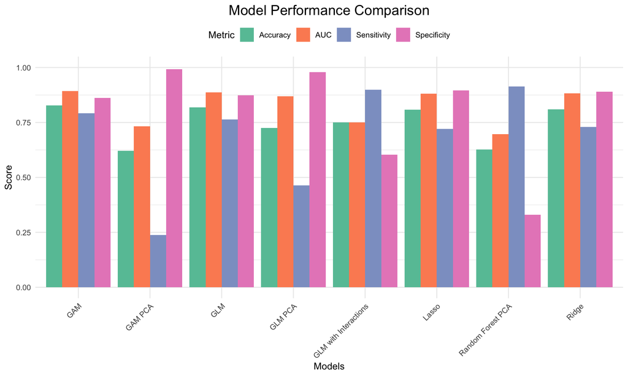

```r
# Create long format data for plotting
performance_long <- final_models_performance %>%
  pivot_longer(
    cols = c(Accuracy, Sensitivity, Specificity, AUC),
    names_to = "Metric",
    values_to = "Value"
  )

# Create plots
ggplot(performance_long, aes(x = Model, y = Value, fill = Metric)) +
  geom_bar(stat = "identity", position = "dodge") +
  scale_fill_brewer(palette = "Set2") +
  theme_minimal() +
  theme(
    axis.text.x = element_text(angle = 45, hjust = 1),
    plot.title = element_text(hjust = 0.5, size = 16),
    legend.position = "top"
  ) +
  labs(
    title = "Model Performance Comparison",
    x = "Models",
    y = "Score"
  ) +
  ylim(0, 1)
```

# 2 Conclusion: Model Selection for KOI Analysis

This analysis aimed to determine the most effective model for classifying Kepler Objects of Interest (KOIs) as either “CANDIDATE” exoplanets or “FALSE POSITIVEs”. Several modeling approaches were explored, including Generalized Linear Models (GLM), Generalized Additive Models (GAM), GLM with interaction terms, Lasso Regression, and Ridge Regression. The performance of these models was evaluated based on Accuracy, Sensitivity, Specificity, and Area Under the ROC Curve (AUC).

## 2.1 Key Findings

**Original Features vs. PCA Features:** Models trained directly on the original (scaled) features generally demonstrated superior performance compared to those trained on PCA features in this analysis. The GLM, GAM, Lasso, and Ridge models using original features all achieved AUCs above 0.88, whereas the models using PCA features had lower AUCs (0.70-0.87) and often exhibited extreme trade-offs between Sensitivity and Specificity, potentially influenced by the definition of the positive class during evaluation. This suggests that PCA, as implemented here, might have resulted in some information loss detrimental to predictive performance for this specific task compared to using the original, interpretable features.

## 2.2 Interpretation and Model Efficacy

The initial **GLM** provided a foundational understanding, identifying several significant predictors for exoplanet disposition. However, residual analysis indicated that linear relationships were insufficient for many variables, suggesting the need for more complex models. Iterations on the GLM involved outlier removal and handling multicollinearity by removing variables like `koi_sma` and `koi_ldm_coeff2`, which led to an improved AIC and better model fit compared to the initial GLM. Key predictors consistently associated with “FALSE POSITIVE” status in the refined GLM included `koi_duration`, `koi_depth`, `koi_teq`, `koi_slogg`, `koi_smass`, `koi_impact`, `koi_ror`, and `koi_dor`. Conversely, higher `koi_insol`, `koi_steff` (though this flipped in the GAM), `koi_incl`, and `koi_smet` were associated with a higher likelihood of being a “CANDIDATE”.

**Lasso Regression** performed feature selection, shrinking several coefficients to zero. Key predictors for “FALSE POSITIVE” included `koi_ror`, `koi_teq`, and `koi_depth`, while `koi_incl` and `koi_smet` were important for “CANDIDATE” status. Its performance was comparable to the refined GLM but did not surpass the GAM.

**Ridge Regression**, which shrinks coefficients but doesn’t typically perform variable elimination, also yielded results similar to the Lasso and refined GLM models. Strong predictors for “FALSE POSITIVE” included `koi_teq`, `koi_depth`, and `koi_ror`, while `koi_incl` and `koi_smet` were significant for “CANDIDATE”.

## 2.3 Overall conclusion

The GAM’s ability to flexibly model the impact of variables like equilibrium temperature (`koi_teq`), stellar surface gravity (`koi_slogg`), planet-star distance over star radius (`koi_dor`), and stellar metallicity (`koi_smet`) as non-linear effects, while retaining strong linear predictors like the planet-to-star radius ratio (`koi_ror`), provides a more robust and accurate framework for distinguishing true exoplanet candidates from false positives in this dataset.